# umiAnalyzer vignette

Stefan Filges

2019-09-28

# Introduction

umiAnalyzer provides tools for analyzing umierrorcorrect output.

## Using the umiVisualiser shiny app

The shiny app requires the shiny, shinyFiles, tidyverse and DT packages and can be run using the following command:

```r
library(umiAnalyzer)

runUmiVisualiser()
```

## How to make your own umiExperiment object

Define a variable containing the path to the directory with all the umierrorcorrect output folders belonging to your experiment. umiAnalyzer comes with raw test data generated with umierrorcorrect that you can import if you don’t have any of your own.

Call the createUmiExperiment to create your umiExperiment object.

```r
library(umiAnalyzer)
```

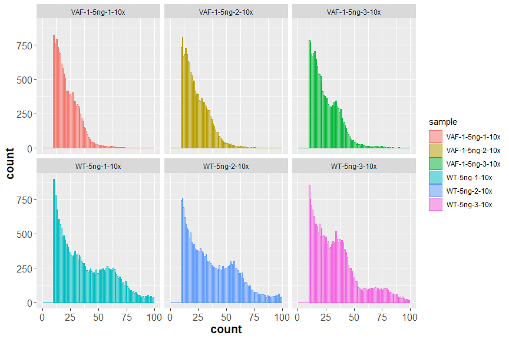

```r
main <- system.file("extdata", package = "umiAnalyzer")

samples <- list.dirs(path = main, full.names = FALSE, recursive = FALSE)

simsen <- createUmiExperiment(experimentName = "simsen",
                              mainDir = main,
                              sampleNames = samples)

reads <- parseBamFiles(mainDir = main, sampleNames = samples, consDepth = 10)

plotFamilyHistogram(reads)
```

createUmiExperiment has an optional flag importBam, which is set to FALSE by default. If this is set to TRUE it will automatically call parseBamFiles and store the read data in the ‘simsen’ object which can then be passed directly to plotFamilyHistogram, without having to run parseBamFiles again. Note that for large experiments, especially if consDepth is set lower than 10, the size of the experiment object may become too large.

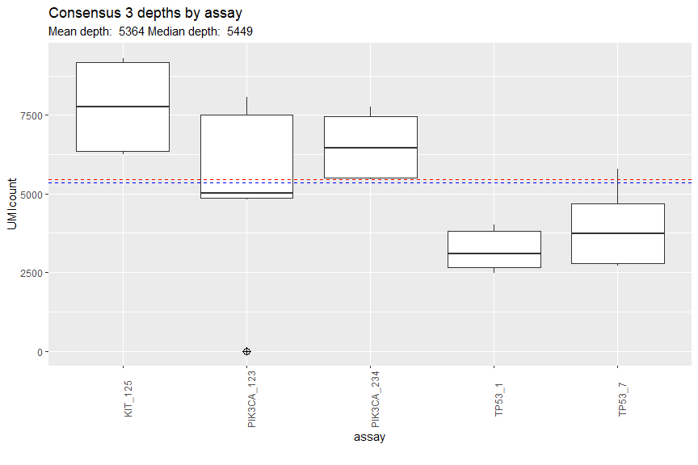

```r
simsen <- generateQCplots(simsen, do.plot = TRUE, group.by = "assay")
```

```r
simsen <- filterUmiobject(
  object = simsen, name = "myfilter", minDepth = 3,
  minCoverage = 100, minFreq = 0, minCount = 0
)

myfilter <- getFilterdData(object = simsen, name = "myfilter")
myfilter
```

```
#> $myfilter
#> # A tibble: 1,686 x 18
#>    `Sample Name` Contig Position Name  Reference     A     C     G     T
#>    <chr>         <chr>     <dbl> <chr> <chr>     <dbl> <dbl> <dbl> <dbl>
#>  1 VAF-1-5ng-1-~ chr17   7673746 TP53~ T             0     0     0  2809
#>  2 VAF-1-5ng-1-~ chr17   7673747 TP53~ C             0  2809     0     0
#>  3 VAF-1-5ng-1-~ chr17   7673748 TP53~ T             1     0     0  2808
#>  4 VAF-1-5ng-1-~ chr17   7673749 TP53~ T             0     0     0  2809
#>  5 VAF-1-5ng-1-~ chr17   7673750 TP53~ G             0     0  2809     0
#>  6 VAF-1-5ng-1-~ chr17   7673751 TP53~ C             0  2810     0     0
#>  7 VAF-1-5ng-1-~ chr17   7673752 TP53~ G             0     0  2810     0
#>  8 VAF-1-5ng-1-~ chr17   7673753 TP53~ G             0     0  2810     0
#>  9 VAF-1-5ng-1-~ chr17   7673754 TP53~ A          2810     0     0     0
#> 10 VAF-1-5ng-1-~ chr17   7673755 TP53~ G             0     0  2809     1
#> # ... with 1,676 more rows, and 9 more variables: I <dbl>, D <dbl>,
#> #   N <dbl>, Coverage <dbl>, `Consensus group size` <dbl>, `Max Non-ref
#> #   Allele Count` <dbl>, `Max Non-ref Allele Frequency` <dbl>, `Max
#> #   Non-ref Allele` <chr>, sample <chr>
```

Next we generate plots for the amplicons and samples in the umiExperiment object.

If generateAmpliconPlots is called and the number of amplicons and samples is too large to plot all of them individually in a single plot the data is shown in summarised form. The user can specify amplicons and or samples optionally to plot only the selection.

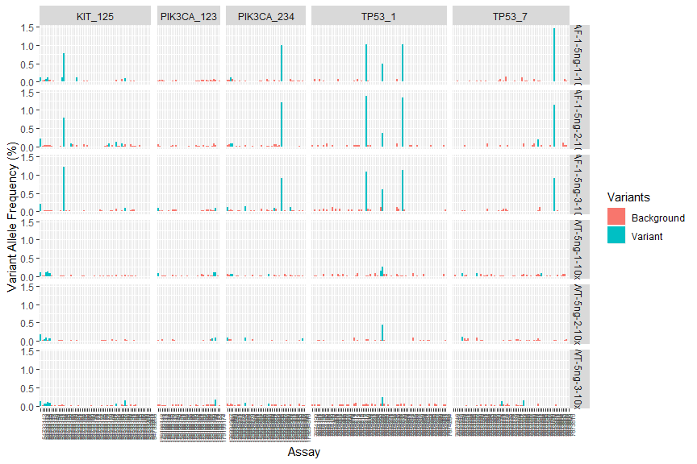

```r
simsen <- generateAmpliconPlots(object = simsen,
                                filter.name = "myfilter",
                                do.plot = TRUE)
```

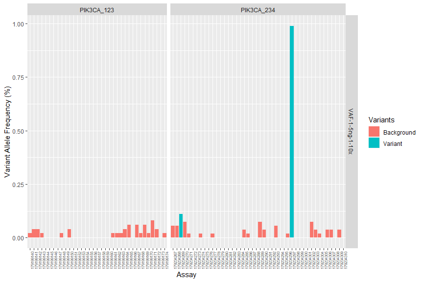

```r
simsen <- generateAmpliconPlots(object = simsen,
                                filter.name = "myfilter",
                                do.plot = TRUE,
                                amplicons = c("PIK3CA_123", "PIK3CA_234"),
                                samples = "VAF-1-5ng-1-10x")
```

```r
metaData <- system.file("extdata", "metadata.txt", package = "umiAnalyzer")
simsen <- importDesign(object = simsen, file = metaData)

simsen <- mergeTechnicalReplicates(object = simsen, filter.name = "myfilter")
```

[figure not shown]

[figure not shown]

```r
simsen@merged.data
```

```
#> # A tibble: 562 x 18
#> # Groups:   Name, Contig, Position, Reference [?]
#>    Name  Contig Position Reference replicate avg.A   avg.T   avg.C   avg.G
#>    <chr> <chr>  <fct>    <chr>     <fct>     <dbl>   <dbl>   <dbl>   <dbl>
#>  1 KIT_~ chr4   54733142 G         1         0.405 8.06e-1 0.      7.57e+3
#>  2 KIT_~ chr4   54733142 G         2         0.825 1.64e+0 2.71e-1 7.57e+3
#>  3 KIT_~ chr4   54733143 G         1         1.19  0.      0.      7.58e+3
#>  4 KIT_~ chr4   54733143 G         2         1.65  2.81e-1 0.      7.58e+3
#>  5 KIT_~ chr4   54733144 T         1         0     7.58e+3 0.      0.
#>  6 KIT_~ chr4   54733144 T         2         0     7.58e+3 0.      2.74e-1
#>  7 KIT_~ chr4   54733145 C         1         0     0.      7.58e+3 4.02e-1
#>  8 KIT_~ chr4   54733145 C         2         0     8.32e-1 7.58e+3 0.
#>  9 KIT_~ chr4   54733146 T         1         0     7.58e+3 0.      0.
#> 10 KIT_~ chr4   54733146 T         2         0     7.58e+3 0.      0.
#> # ... with 552 more rows, and 9 more variables: avg.N <dbl>, avg.I <dbl>,
#> #   avg.D <dbl>, avg.Depth <dbl>, std.Depth <dbl>, avg.Max.AF <dbl>,
#> #   std.MaxAF <dbl>, avg.MaxAC <dbl>, std.MaxAC <dbl>
```

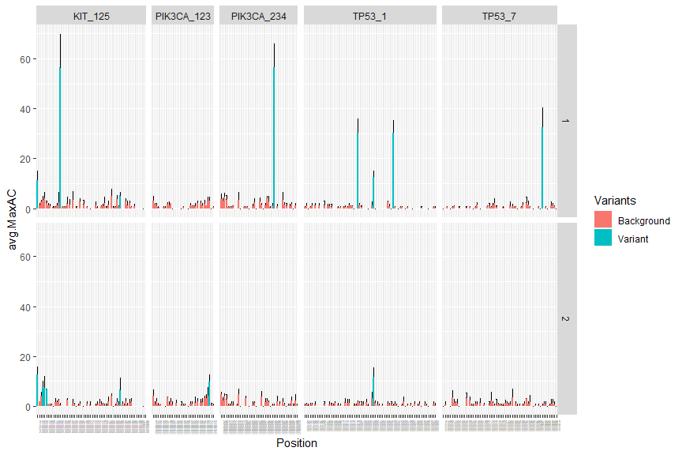

```r
vizMergedData(simsen)
```

# Calling variants

umiAnalyzer comes with a build-in umiExperiment object to explore, which was generated using the code above, so it can be used without creating the it first if so desired.

In order to call variants using the umiAnalyzer variant caller simply load the package and test data and use the callVariants function. You can then filter the resulting consensus data (cons.data) within the object, e.g. for significant variants.

```r
data <- simsen
data <- callVariants(data)

data <- filterVariants(object = data, p.adjust = 0.2, minDepth = 5)
```

# Importing experimental designs and statistics

## Experimental design

umiAnalyzer supports adding meta data to a UMIsample or UMIexperiment object, such as experimental design matrices or clinical parameters. This is done using the importDesign function and requires a simple formatted table supplied by the user as a tab separated file. It is important that the order of the samples in the meta data file is the same as when building the UMIexperiment object.

```r
metaData <- system.file("extdata", "metadata.txt", package = "umiAnalyzer")

data <- importDesign(object = simsen, file = metaData)
```

## Working with meta data

It is also possible to add meta data to an object and to retrieve metadata if needed. The design matrix loaded with importDesign can be retrieved as follows:

```r
design <- getMetaData(object = data, attributeName = "design")

design
```

Similarly, any kind of meta data can be added and retrieved from an object using addMetaData:

```r
comment <- "fix this"
data <- addMetaData(object = data, attributeName = "my-comment", attributeValue = comment)

myattribute <- getMetaData(object = data, attributeName = "my-comment")
myattribute
```

# Other functions (experimental)

## Writing a Variant Call file (vcf)

```r
generateVCF(object = simsen, outFile = 'simsen.vcf', printAll = FALSE, save = FALSE)
```

## Saving consensus data as a csv file

It is possible to retrieve consensus data as a tibble using saveConsData. This function can also be used to to save the data as a csv file with delimiters either ‘,’, ‘;’ or tab. This requires the user to set the save parameter to TRUE and to specify an output directory (default is the working directory), filename (default is ‘consensus_data.csv’) and delimiter (default is ‘;’).

```r
consensus_data <- saveConsData(object = simsen)

outDir <- "~/Documents/"
saveConsData(object = simsen, outDir = outDir, delim = ";", save = TRUE)
```